# Basic Inferential Data Analysis

krrish16

18 August 2018

## PART-2 Overview

The purpose of the this data analysis is to analyze the ToothGrowth data set by comparing the guinea tooth growth by supplement and dose. First the exploratory data analysis is performed on the data set. Then comparison with confidence intervals is done in order to make conclusions about the tooth growth.

## Loading Data Set

```r
library(datasets)
library(ggplot2)
data(ToothGrowth)
str(ToothGrowth)
```

```
## 'data.frame':    60 obs. of  3 variables:
##  $ len : num  4.2 11.5 7.3 5.8 6.4 10 11.2 11.2 5.2 7 ...
##  $ supp: Factor w/ 2 levels "OJ","VC": 2 2 2 2 2 2 2 2 2 2 ...
##  $ dose: num  0.5 0.5 0.5 0.5 0.5 0.5 0.5 0.5 0.5 0.5 ...
```

## Summary of Data

```r
summary(ToothGrowth)
```

```
##       len        supp         dose
##  Min.   : 4.20   OJ:30   Min.   :0.500
##  1st Qu.:13.07   VC:30   1st Qu.:0.500
##  Median :19.25           Median :1.000
##  Mean   :18.81           Mean   :1.167
##  3rd Qu.:25.27           3rd Qu.:2.000
##  Max.   :33.90           Max.   :2.000
```

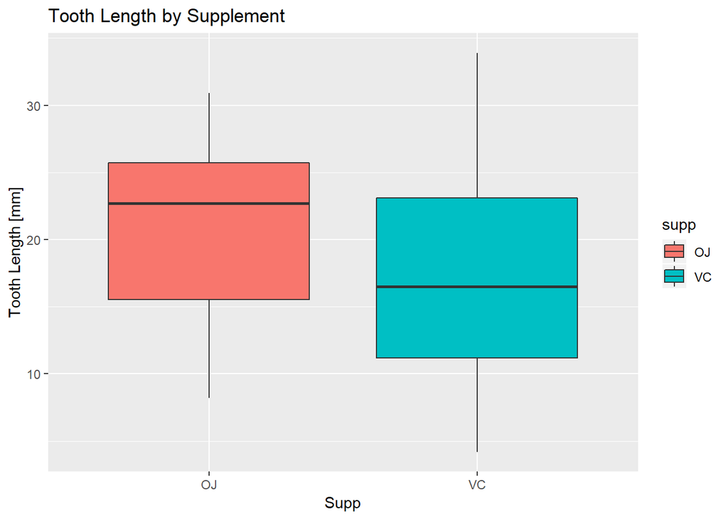

```r
t <- ToothGrowth

ggplot(t, aes(x = supp, y = len)) + geom_boxplot(aes(fill = supp)) + xlab("Supp") + ylab("Tooth Length [mm]") + ggtitle("Tooth Length by Supplement")
```

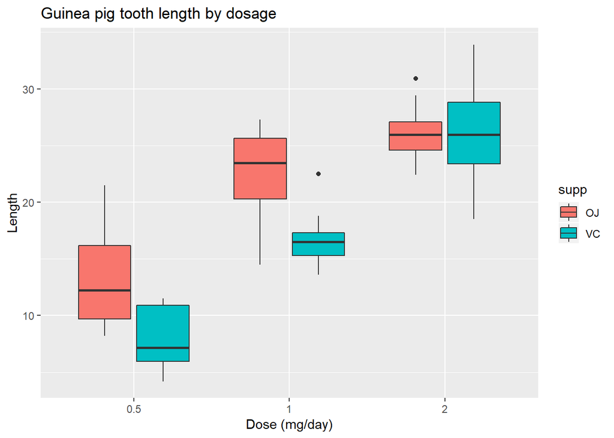

```r
ggplot(t, aes(x=factor(dose), y=len)) + geom_boxplot(aes(fill = supp)) + labs(title="Guinea pig tooth length by dosage", x="Dose (mg/day)", y="Length")
```

From the plot it is clear that increasing the dosage increases the tooth growth. Orange juice(OJ) is more effective than Ascorbic acid(VC) for tooth growth when the dosage is 0.5 and 1.0 mg/day and are equally effective when the dosage is 2.0 mg/day.

## Performing Hypothesis Tests

```r
unique(ToothGrowth$dose)
```

```
## [1] 0.5 1.0 2.0
```

Hypothesis - 1 : Dosage = 0.5 mg/day

```r
t.test(len ~ supp, data = subset(t, dose == 0.5))
```

```
##
##  Welch Two Sample t-test
##
## data:  len by supp
## t = 3.1697, df = 14.969, p-value = 0.006359
## alternative hypothesis: true difference in means is not equal to 0
## 95 percent confidence interval:
##  1.719057 8.780943
## sample estimates:
## mean in group OJ mean in group VC
##            13.23             7.98
```

Hypothesis - 2 : Dosage = 1 mg/day

```r
t.test(len ~ supp, data = subset(t, dose == 1))
```

```
##
##  Welch Two Sample t-test
##
## data:  len by supp
## t = 4.0328, df = 15.358, p-value = 0.001038
## alternative hypothesis: true difference in means is not equal to 0
## 95 percent confidence interval:
##  2.802148 9.057852
## sample estimates:
## mean in group OJ mean in group VC
##            22.70            16.77
```

Hypothesis - 3 : Dosage = 2 mg/day

```r
t.test(len ~ supp, data = subset(t, dose == 2))
```

```
##
##  Welch Two Sample t-test
##
## data:  len by supp
## t = -0.046136, df = 14.04, p-value = 0.9639
## alternative hypothesis: true difference in means is not equal to 0
## 95 percent confidence interval:
##  -3.79807  3.63807
## sample estimates:
## mean in group OJ mean in group VC
##            26.06            26.14
```

## Assumptions and Conclusion

Conclusion from the exploratory data analyses indicate overall orange juice (OJ) increase tooth length more effectively than ascorbic acid vitamin C (VC).

1.When the guinea pigs received 0.5 mg dosage per day, OJ has higher mean tooth length of 13.23 compared to VC mean tooth length 7.98.

2.When the guinea pigs received 1 mg dosage per day, OJ has higher mean tooth length of 22.70 vs. VC mean tooth length 16.77.

3.However, when the guinea pigs received 2 mg dosage per day, the mean tooth length difference is very little, OJ has mean tooth length 26.06 and VC has mean tooth length 26.14.